# Modelo para decesos basado en casos, Covid 19

Se postula un modelo sencillo para determinar los decesos basados en el número de casos en cada país. Si bien de inmediato se aprecia que el problema se puede resolver por regresión, tenemos los siguientes problemas:

- La serie de datos es corta, menor a 100 casos (hasta el momento)
- Existe un desfase entre la presencia de casos nuevos y los decesos, que es relativamente variable.
- Las diferencias en las tasas de letalidad no solamente se pueden atribuir a las condiciones de los pacientes, sino también a la capacidad de testeo, a las reglas para establecer cuando un deceso se atribuye a Covid y a las condiciones sanitarias de cada país.

La presencia de múltiples series nos permite de alguna solucionar el primer modelo, ya que podemos generar un modelo general, el cual tenga ajuste para el caso particular. Para el segundo problema, se puede adoptar una solución empírica de fuerza bruta, que es considerar un rango aceptable de tiempo desde que surge un caso nuevo y el deceso de un porcentaje de estos, usando regularización para solucionar el problema de los múltiples coeficientes necesarios en la serie. Con respecto al tercer problema, se puede asumir que las estadísticas de deceso son válidas condicional a la selección de un país, siendo el modelo general un apoyo para los casos en que no se cuente con suficiente información.

Como primera metodología a probar, usaremos un modelo de regressión simple utilizando los datos de casos con lag entre 1 y 20 días.

```r
library(rms)
```

Ahora, debemos construir una base de datos que nos permita realizar un análisis de regresión adecuado. Para ello, se tendrán como columnas el día, fecha, pais, numero de casos y decesos nuevos por día.

```r
a.0<-lapply(cn.cases.10,function(pais) {
  x<-data.frame(WHO_SR[,c("SituationReport","Date")],
             pais=pais,
             casos=WHO_SR[,pais],
             decesos=WHO_SR[,paste0(pais,".deaths")])
  casos<-x$casos

  for(i in 1:20) {
    print(casos[(i+1):(n-i)])
    x[[paste0("casos.",i)]]<-c(rep(0,i), casos[1:(n-i)])
  }
  x
})
```

[output not shown]

[output cut: 2018 more lines]

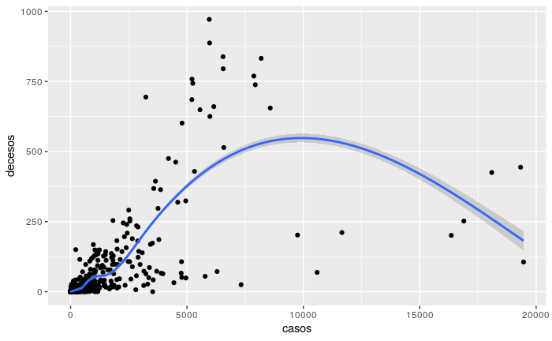

Podemos ver que la serie de China sufre un salto abrupo (color rojo)

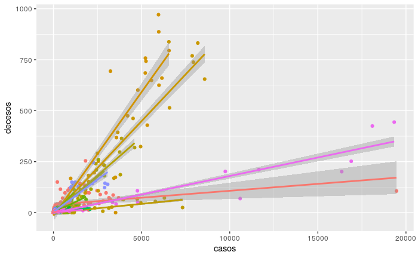

Haciendo el gráfico respectivo para China, es fácil verificar lo antes dicho. Si bien es un caso muy importante, este cambio en la secuencia de casos es bastante difícil de modelar. Por lo tanto, lo eliminaremos de la secuencia.

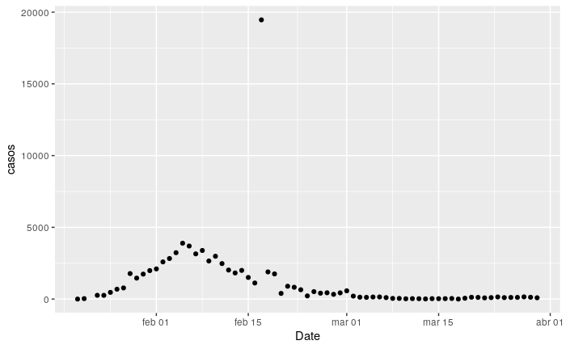

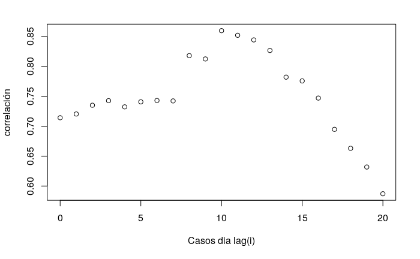

Si ploteamos esta relación, podemos ver en algunos países se observan relaciones aproximadamente lineales.

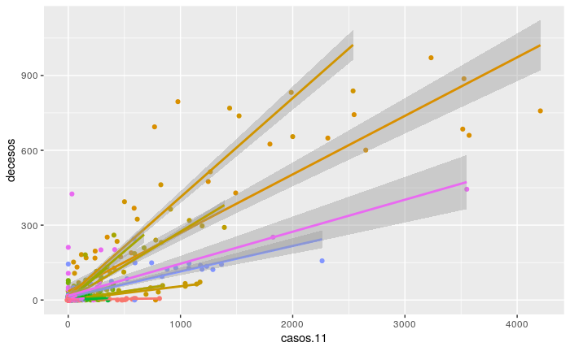

## Modelo de regresión simple

Un modelo bastante sencillo es usar un modelo de interacción del país con el número de casos con lag 0 a 20. Por cada país, tenemos un total de 21 coeficientes propios, lo que genera un total de 2451 grados de libertad para 3570 grados. El R²=0.999, con R²adj=0.99, lo que indica una gran capacidad de predicción.

```r
summary(lm.1)
```

```
Call:
lm(formula = decesos ~ pais * (casos + casos.1 + casos.2 + casos.3 +
    casos.4 + casos.5 + casos.6 + casos.7 + casos.8 + casos.9 +
    casos.10 + casos.11 + casos.12 + casos.13 + casos.14 + casos.15 +
    casos.16 + casos.17 + casos.18 + casos.19 + casos.20), data = a2)

Residuals:
    Min      1Q  Median      3Q     Max
-49.285  -0.010   0.000   0.015  24.380

Coefficients: (3 not defined because of singularities)
                                     Estimate Std. Error t value Pr(>|t|)
(Intercept)                         2.709e-01  3.781e-01   0.717 0.473711
paisAustralia                      -2.143e-01  5.321e-01  -0.403 0.687181
paisMalaysia                       -3.448e-01  5.048e-01  -0.683 0.494553
paisJapan                          -4.165e-01  5.477e-01  -0.760 0.447070
paisPhilippines                    -2.223e-01  4.893e-01  -0.454 0.649602
paisItaly                          -1.664e+00  5.199e-01  -3.201 0.001386 **
paisSpain                          -4.998e-01  4.949e-01  -1.010 0.312597
paisGermany                        -3.617e-01  4.920e-01  -0.735 0.462270
paisFrance                         -6.635e-01  4.995e-01  -1.328 0.184230
paisSwitzerland                    -2.512e-01  5.038e-01  -0.499 0.618150
paisUnitedKingdom                  -7.186e-01  4.927e-01  -1.459 0.144785
paisNetherlands                    -2.873e-01  5.035e-01  -0.571 0.568386
paisAustria                        -2.697e-01  4.934e-01  -0.547 0.584683
paisBelgium                        -3.265e-01  5.010e-01  -0.652 0.514725
paisNorway                         -2.786e-01  5.047e-01  -0.552 0.581044
paisSweden                         -2.511e-01  4.981e-01  -0.504 0.614190
paisPortugal                       -2.730e-01  4.939e-01  -0.553 0.580527
paisDenmark                        -2.723e-01  4.933e-01  -0.552 0.580934
paisTurkey                         -2.709e-01  4.890e-01  -0.554 0.579590
paisCzechia                        -2.684e-01  4.936e-01  -0.544 0.586644
paisIreland                        -2.655e-01  4.907e-01  -0.541 0.588564
paisLuxembourg                     -2.732e-01  4.915e-01  -0.556 0.578338
paisPoland                         -2.696e-01  5.002e-01  -0.539 0.589967
paisFinland                        -2.707e-01  4.926e-01  -0.549 0.582725
paisGreece                         -2.804e-01  5.040e-01  -0.556 0.578050
paisRomania                        -2.688e-01  4.913e-01  -0.547 0.584357
paisSlovenia                       -2.720e-01  4.923e-01  -0.553 0.580617
paisHungary                        -2.735e-01  5.008e-01  -0.546 0.585072
```

[output cut: 164 more lines]

```
paisLuxembourg:casos.2              3.457e-02  7.385e-01   0.047 0.962662
paisPoland:casos.2                 -6.510e-03  3.499e-01  -0.019 0.985155
paisFinland:casos.2                -2.412e-04  4.512e-02  -0.005 0.995735
paisGreece:casos.2                 -5.099e-03  4.095e-02  -0.125 0.900914
paisRomania:casos.2                -1.780e-03  1.031e-01  -0.017 0.986228
paisSlovenia:casos.2                2.554e-03  2.122e-01   0.012 0.990399
paisHungary:casos.2                -2.938e-02  2.951e-01  -0.100 0.920684
paisSanMarino:casos.2               2.794e-03  1.029e-01   0.027 0.978340
 [ reached getOption("max.print") -- omitted 922 rows ]
---
Signif. codes:  0 ‘***’ 0.001 ‘**’ 0.01 ‘*’ 0.05 ‘.’ 0.1 ‘ ’ 1

Residual standard error: 2.215 on 2451 degrees of freedom
Multiple R-squared:  0.999, Adjusted R-squared:  0.9986
F-statistic:  2238 on 1118 and 2451 DF,  p-value: < 2.2e-16
```

Si estudiamos los supuestos, podemos observar que hay falta de linealidad para predecir pocos decesos. Los residuos no presentan distribución normal y hay problemas en la varianza de los valores predichos inferiores a 0.

[output not shown]

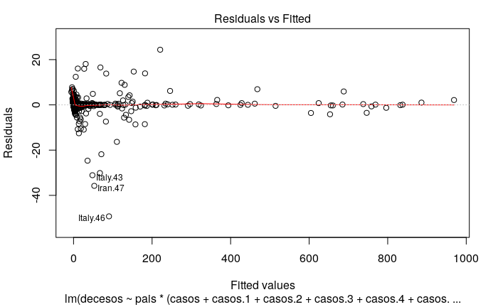

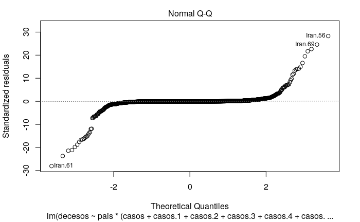

[output not shown]

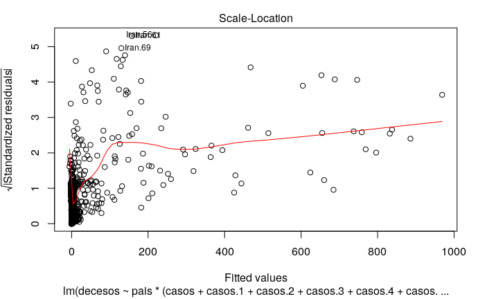

```
Se han producido NaNsSe han producido NaNs
```

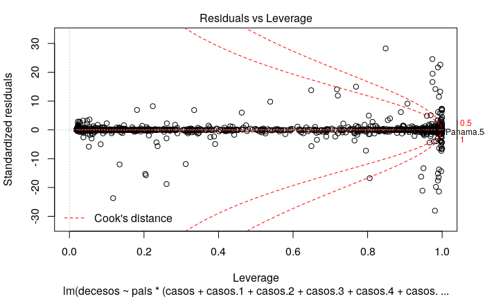

```r
plot(lm.1)
```

Una solución rápida es eliminar todas aquellas filas donde hay 0 casos y 0 decesos.

```r
a3
```

[output not shown]

```r
lm.2<-lm(decesos~pais*(casos.0+casos.1+casos.2+casos.3+casos.4+casos.5+casos.6+casos.7+casos.8+casos.9+casos.10+casos.11+casos.12+casos.13+casos.14+casos.15+casos.16+casos.17+casos.18+casos.19+casos.20),a3)
lm.2<-lm(decesos~pais*(casos.0+casos.1+casos.2+casos.3+casos.4+casos.5+casos.6+casos.7+casos.8+casos.9+casos.10+casos.11+casos.12+casos.13+casos.14+casos.15+casos.16+casos.17+casos.18+casos.19+casos.20),a3)
summary(lm.2)
```

```
Call:
lm(formula = decesos ~ pais * (casos.0 + casos.1 + casos.2 +
    casos.3 + casos.4 + casos.5 + casos.6 + casos.7 + casos.8 +
    casos.9 + casos.10 + casos.11 + casos.12 + casos.13 + casos.14 +
    casos.15 + casos.16 + casos.17 + casos.18 + casos.19 + casos.20),
    data = a3)

Residuals:
    Min      1Q  Median      3Q     Max
-49.157  -0.045   0.000   0.053  23.324

Coefficients: (4 not defined because of singularities)
                                     Estimate Std. Error t value Pr(>|t|)
(Intercept)                         2.969e-01  6.414e-01   0.463 0.643549
paisAustralia                      -2.329e-01  9.093e-01  -0.256 0.797883
paisMalaysia                       -3.803e-01  8.619e-01  -0.441 0.659117
paisJapan                          -4.638e-01  9.403e-01  -0.493 0.621953
paisPhilippines                    -2.216e-01  8.963e-01  -0.247 0.804737
paisItaly                          -2.179e+00  9.290e-01  -2.345 0.019218 *
paisSpain                          -5.936e-01  8.708e-01  -0.682 0.495642
paisGermany                        -4.026e-01  8.452e-01  -0.476 0.633935
paisFrance                         -7.268e-01  8.472e-01  -0.858 0.391214
paisSwitzerland                    -1.908e-01  1.405e+00  -0.136 0.892042
paisUnitedKingdom                  -8.736e-01  8.653e-01  -1.010 0.312976
paisNetherlands                    -4.111e-01  1.562e+00  -0.263 0.792520
paisAustria                        -2.923e-01  1.191e+00  -0.245 0.806170
paisBelgium                        -4.003e-01  9.693e-01  -0.413 0.679757
paisNorway                         -3.458e-01  1.513e+00  -0.229 0.819216
paisSweden                         -2.667e-01  9.118e-01  -0.293 0.769959
paisPortugal                       -3.118e-01  1.538e+00  -0.203 0.839433
paisDenmark                        -3.027e-01  1.224e+00  -0.247 0.804682
paisTurkey                         -2.917e-01  5.522e+00  -0.053 0.957881
paisCzechia                        -2.810e-01  1.443e+00  -0.195 0.845681
paisIreland                        -2.698e-01  1.297e+00  -0.208 0.835275
paisLuxembourg                     -3.100e-01  1.374e+00  -0.226 0.821542
paisPoland                         -2.742e-01  2.261e+00  -0.121 0.903509
paisFinland                        -2.966e-01  8.942e-01  -0.332 0.740244
paisGreece                         -3.549e-01  1.485e+00  -0.239 0.811193
paisRomania                        -2.886e-01  1.190e+00  -0.243 0.808400
paisSlovenia                       -3.066e-01  1.677e+00  -0.183 0.854939
```

[output cut: 165 more lines]

```
paisLuxembourg:casos.2              3.392e-02  1.199e+00   0.028 0.977432
paisPoland:casos.2                 -9.052e-03  6.199e-01  -0.015 0.988353
paisFinland:casos.2                -2.368e-04  7.319e-02  -0.003 0.997419
paisGreece:casos.2                 -3.747e-03  7.458e-02  -0.050 0.959944
paisRomania:casos.2                -1.965e-03  1.691e-01  -0.012 0.990734
paisSlovenia:casos.2                2.075e-03  3.534e-01   0.006 0.995316
paisHungary:casos.2                -2.036e-02  5.920e-01  -0.034 0.972569
paisSanMarino:casos.2              -2.112e-03  1.872e-01  -0.011 0.991003
 [ reached getOption("max.print") -- omitted 922 rows ]
---
Signif. codes:  0 ‘***’ 0.001 ‘**’ 0.01 ‘*’ 0.05 ‘.’ 0.1 ‘ ’ 1

Residual standard error: 3.589 on 924 degrees of freedom
Multiple R-squared:  0.999, Adjusted R-squared:  0.9978
F-statistic: 840.2 on 1117 and 924 DF,  p-value: < 2.2e-16
```

Eliminar estos casos, si bien facilita el cálculo del proceso, no cambia los problemas del modelo. En particular, existe una gran cantidad de casos que presentan residuos muy grandes, con muy alto leverage.

[output not shown]

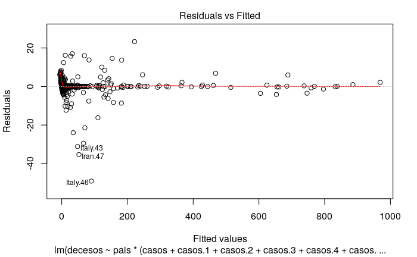

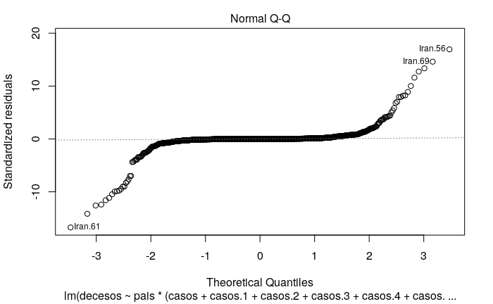

[output not shown]

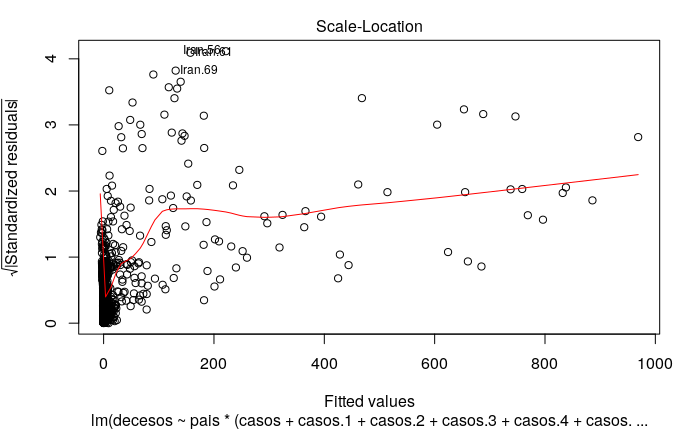

```
Se han producido NaNsSe han producido NaNs
```

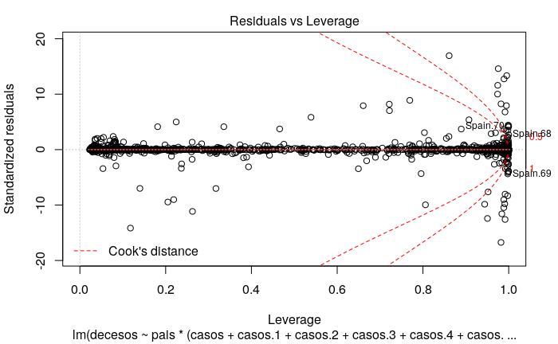

```r
plot(lm.2)
```

## Regularización

El modelo anterior, si bien parece predecir bien los casos, tiene el problema que puede resultar muy inestable. Probemos usando regularización en cada modelo por país, para detectar si existe un patrón común.

Usemos Italia como ejemplo. Podemos ver que el coeficiente para 7 días aparece primero y es muy estable. El tercero, que también es muy estable, es el de 14 días.

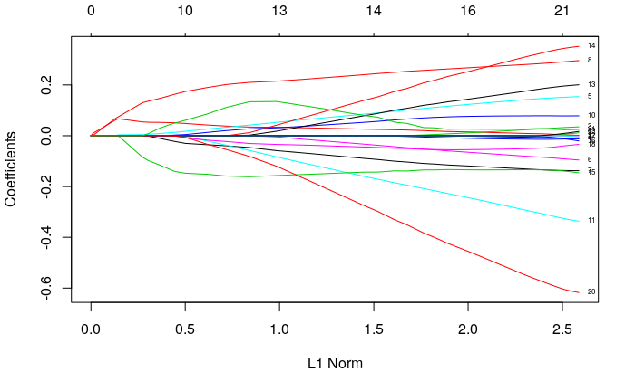

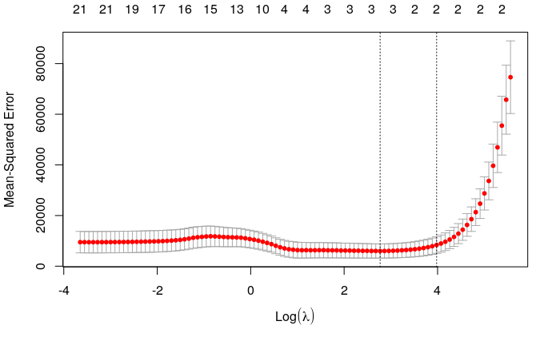

El lambda mínimo se encuentra con lambda=15.96. Se suele usar el modelo más sencillo que esté a una desviación estándar de este mínimo, que sería 53.5

| minimo | de1 |
| --- | --- |
| 15.9652 | 53.50899 |

En este caso, podemos ver que el modelo solo requiere el uso de los casos del día anterior y los de 7 días atrás.

```r
coef(cvfit, s="lambda.1se")
```

```
22 x 1 sparse Matrix of class "dgCMatrix"
                      1
(Intercept) 28.99538718
casos.0      .
casos.1      0.05608110
casos.2      .
casos.3      .
casos.4      .
casos.5      .
casos.6      .
casos.7      0.06028935
casos.8      .
casos.9      .
casos.10     .
casos.11     .
casos.12     .
casos.13     .
casos.14     .
casos.15     .
casos.16     .
casos.17     .
casos.18     .
casos.19     .
casos.20     .
```

Si observamos la correlación entre el valor predicho y el observado, es de 0.97

```r
cor(pr.1,yy)
```

```
       [,1]
1 0.9720964
```

Si ploteamos la relación, vemos que es aproximadamente lineal.

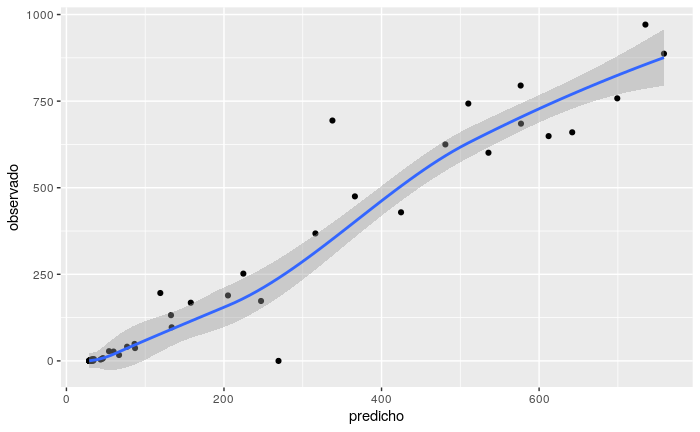